# What is nonlinear trajectory modelling with splines?

2023 Research Methods e-Festival, Ahmed Elhakeem (a.elhakeem@bristol.ac.uk), 09-11-2023

# Load packages

```r
library(tidyverse); library(lme4); library(mgcv); library(sitar); library(lspline); library(splines); library(broom.mixed); library(ggeffects); library(metafor)
```

# Load BMI dataset

```r
dat <- read.csv((
  "https://raw.githubusercontent.com/aelhak/NCRM2023/main/bmi_long.csv")) %>%
  mutate(id = as.factor(id), sex = as.factor(sex))

dat_m <- dat %>% filter(sex == "M")
dat_f <- dat %>% filter(sex == "F")
```

Quick look at the data

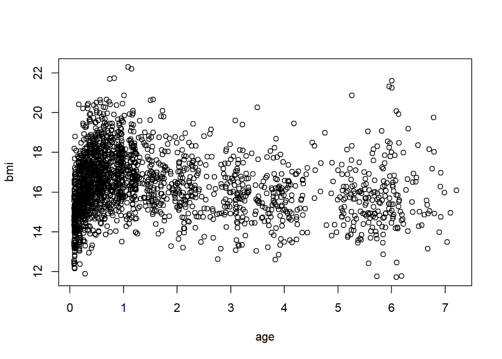

```r
with(dat, plot(age, bmi))
```

```r
dat %>% group_by(sex) %>% summarise(N = n_distinct(id))
```

```
## # A tibble: 2 × 2
##   sex       N
##   <fct> <int>
## 1 F       100
## 2 M       100
```

```r
dat %>% group_by(id) %>% count() %>% ungroup() %>%
  summarise(median(n), min(n), max(n))
```

```
## # A tibble: 1 × 3
##   `median(n)` `min(n)` `max(n)`
##         <dbl>    <int>    <int>
## 1          11        1       21
```

# Linear splines

## Males

Fit models with different knots and select model with lowest BIC

```r
ls_m <- map(3:6, possibly(~ { eval(parse(text = paste0(
  "lmer(bmi ~ qlspline(age, ", .x, ") + (qlspline(age, 2) | id ),
  REML = F, data = dat_m)")))}, otherwise = NA_real_))

(ls_m_best <- ls_m[[which.min(unlist(map(ls_m, BIC)))]])
```

```
## Linear mixed model fit by maximum likelihood  ['lmerMod']
## Formula: bmi ~ qlspline(age, 6) + (qlspline(age, 2) | id)
##    Data: dat_m
##       AIC       BIC    logLik  deviance  df.resid
##  2517.947  2587.365 -1244.974  2489.947      1038
## Random effects:
##  Groups   Name              Std.Dev. Corr
##  id       (Intercept)       1.3953
##           qlspline(age, 2)1 1.6904   -0.50
##           qlspline(age, 2)2 0.2861   -0.10 -0.19
##  Residual                   0.5672
## Number of obs: 1052, groups:  id, 100
## Fixed Effects:
##       (Intercept)  qlspline(age, 6)1  qlspline(age, 6)2  qlspline(age, 6)3
##         14.225165           9.989366           1.759189           1.031496
## qlspline(age, 6)4  qlspline(age, 6)5  qlspline(age, 6)6
##         -0.922343          -0.545598           0.005893
```

Print knots positions

```r
attr(terms(ls_m_best), "predvars")
```

```
## list(bmi, lspline(age, knots = c(`16.66667%` = 0.2545100625,
## `33.33333%` = 0.468764600333333, `50%` = 0.78427165, `66.66667%` = 1.49894777866667,
## `83.33333%` = 3.50837651933333), marginal = FALSE))
```

Plot mean BMI trajectory in males

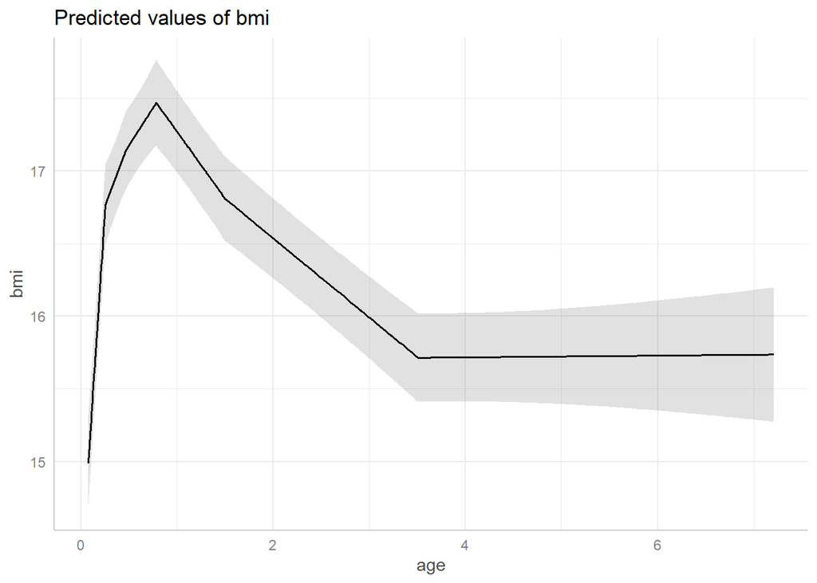

```r
ggeffect(ls_m_best, terms = c("age [all]")) %>% plot()
```

Summarise linear slope for each spline segment

```r
as.data.frame(tidy(ls_m_best, conf.int = T)) %>%
  filter(effect == "fixed") %>% select(-group, -statistic)
```

```
##   effect              term     estimate  std.error    conf.low  conf.high
## 1  fixed       (Intercept) 14.225164592 0.18268349 13.86711153 14.5832177
## 2  fixed qlspline(age, 6)1  9.989365505 0.60956139  8.79464714 11.1840839
## 3  fixed qlspline(age, 6)2  1.759188745 0.47118718  0.83567885  2.6826986
## 4  fixed qlspline(age, 6)3  1.031496335 0.33631433  0.37233236  1.6906603
## 5  fixed qlspline(age, 6)4 -0.922342907 0.13452196 -1.18600110 -0.6586847
## 6  fixed qlspline(age, 6)5 -0.545598388 0.06037489 -0.66393099 -0.4272658
## 7  fixed qlspline(age, 6)6  0.005892826 0.05187636 -0.09578297  0.1075686
```

## Females

Fit models with different knots and select model with lowest BIC

```r
ls_f <- map(3:6, possibly(~ { eval(parse(text = paste0(
  "lmer(bmi ~ qlspline(age, ", .x, ") + (qlspline(age, 2) | id ),
  REML = F, data = dat_f)")))}, otherwise = NA_real_))

(ls_f_best <- ls_f[[which.min(unlist(map(ls_f, BIC)))]])
```

```
## Linear mixed model fit by maximum likelihood  ['lmerMod']
## Formula: bmi ~ qlspline(age, 6) + (qlspline(age, 2) | id)
##    Data: dat_f
##       AIC       BIC    logLik  deviance  df.resid
##  2475.785  2545.069 -1223.892  2447.785      1028
## Random effects:
##  Groups   Name              Std.Dev. Corr
##  id       (Intercept)       1.1397
##           qlspline(age, 2)1 1.3241   -0.25
##           qlspline(age, 2)2 0.2830   -0.36 -0.16
##  Residual                   0.5759
## Number of obs: 1042, groups:  id, 100
## Fixed Effects:
##       (Intercept)  qlspline(age, 6)1  qlspline(age, 6)2  qlspline(age, 6)3
##           14.0023             7.3805             4.8685             0.9477
## qlspline(age, 6)4  qlspline(age, 6)5  qlspline(age, 6)6
##           -0.7870            -0.5159             0.1283
```

Print knots positions

```r
attr(terms(ls_f_best), "predvars")
```

```
## list(bmi, lspline(age, knots = c(`16.66667%` = 0.2500943515,
## `33.33333%` = 0.47417131, `50%` = 0.838830521, `66.66667%` = 1.504477156,
## `83.33333%` = 3.464661673), marginal = FALSE))
```

Plot mean BMI trajectory in females

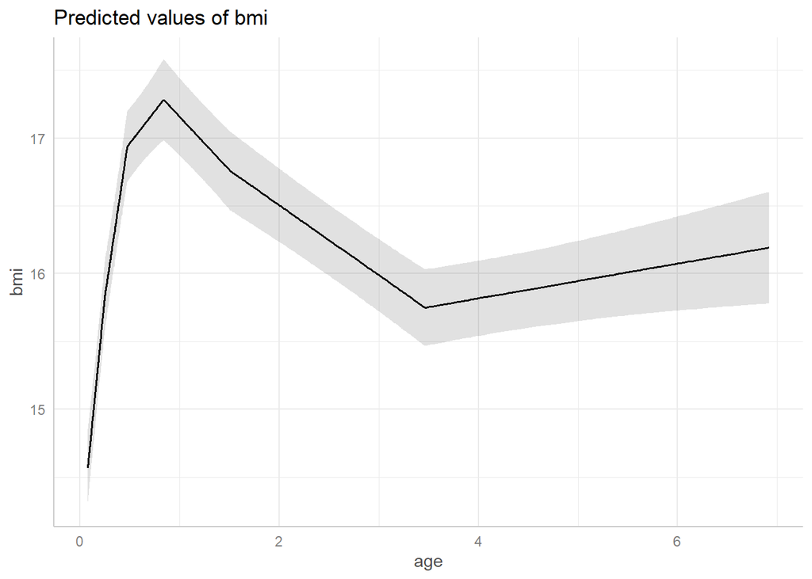

```r
ggeffect(ls_f_best, terms = c("age [all]")) %>% plot()
```

Summarise linear slope for each spline segment

```r
as.data.frame(tidy(ls_f_best, conf.int = T)) %>%
  filter(effect == "fixed") %>% select(-group, -statistic)
```

```
##   effect              term   estimate  std.error    conf.low  conf.high
## 1  fixed       (Intercept) 14.0022676 0.16340497 13.68199970 14.3225354
## 2  fixed qlspline(age, 6)1  7.3804897 0.61801194  6.16920852  8.5917708
## 3  fixed qlspline(age, 6)2  4.8684530 0.43999604  4.00607659  5.7308294
## 4  fixed qlspline(age, 6)3  0.9476956 0.28341660  0.39220926  1.5031819
## 5  fixed qlspline(age, 6)4 -0.7869585 0.14573827 -1.07260026 -0.5013168
## 6  fixed qlspline(age, 6)5 -0.5159321 0.06088616 -0.63526678 -0.3965974
## 7  fixed qlspline(age, 6)6  0.1283030 0.05335102  0.02373688  0.2328691
```

## Males and females combined

Fit models with different knots and select model with lowest BIC

```r
ls_mf <- map(3:6, possibly(~ { eval(parse(text = paste0(
  "lmer(bmi ~ qlspline(age, ", .x, ") * sex + (qlspline(age, 2) | id ),
  REML = F, data = dat)")))}, otherwise = NA_real_))

(ls_mf_best <- ls_mf[[which.min(unlist(map(ls_mf, BIC)))]])
```

```
## Linear mixed model fit by maximum likelihood  ['lmerMod']
## Formula: bmi ~ qlspline(age, 6) * sex + (qlspline(age, 2) | id)
##    Data: dat
##       AIC       BIC    logLik  deviance  df.resid
##  4982.226  5100.810 -2470.113  4940.226      2073
## Random effects:
##  Groups   Name              Std.Dev. Corr
##  id       (Intercept)       1.2704
##           qlspline(age, 2)1 1.5297   -0.39
##           qlspline(age, 2)2 0.2864   -0.22 -0.18
##  Residual                   0.5706
## Number of obs: 2094, groups:  id, 200
## Fixed Effects:
##            (Intercept)       qlspline(age, 6)1       qlspline(age, 6)2
##                14.0082                  7.3494                  4.8078
##      qlspline(age, 6)3       qlspline(age, 6)4       qlspline(age, 6)5
##                 1.1247                 -0.7497                 -0.5154
##      qlspline(age, 6)6                    sexM  qlspline(age, 6)1:sexM
##                 0.1385                  0.2039                  2.6918
## qlspline(age, 6)2:sexM  qlspline(age, 6)3:sexM  qlspline(age, 6)4:sexM
##                -3.0221                 -0.1458                 -0.2008
## qlspline(age, 6)5:sexM  qlspline(age, 6)6:sexM
##                -0.0298                 -0.1366
```

Print knots positions

```r
attr(terms(ls_mf_best), "predvars")
```

```
## list(bmi, lspline(age, knots = c(`16.66667%` = 0.2537449885,
## `33.33333%` = 0.472295410666667, `50%` = 0.799666034, `66.66667%` = 1.50039106733333,
## `83.33333%` = 3.49474118916667), marginal = FALSE), sex)
```

Plot mean BMI trajectory by sex

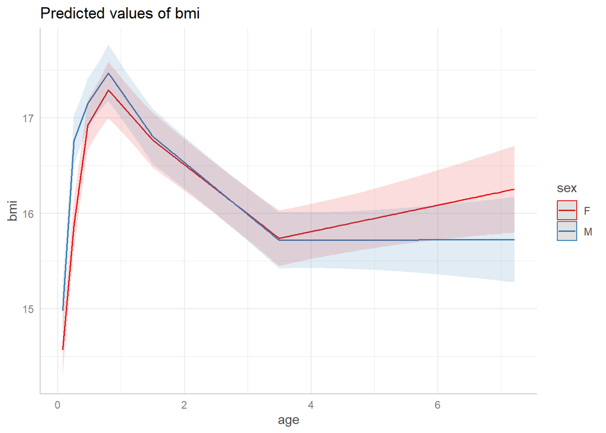

```r
ggeffect(ls_mf_best, terms = c("age [all]", "sex [all]")) %>% plot()
```

Summarise linear slope for each spline segment

```r
as.data.frame(tidy(ls_mf_best, conf.int = T)) %>%
  filter(effect == "fixed") %>% select(-group, -statistic)
```

```
##    effect                   term    estimate  std.error    conf.low
## 1   fixed            (Intercept) 14.00818178 0.17236550 13.67035160
## 2   fixed      qlspline(age, 6)1  7.34938516 0.60553254  6.16256319
## 3   fixed      qlspline(age, 6)2  4.80778719 0.46013214  3.90594477
## 4   fixed      qlspline(age, 6)3  1.12473040 0.31966818  0.49819227
## 5   fixed      qlspline(age, 6)4 -0.74965969 0.13751310 -1.01918042
## 6   fixed      qlspline(age, 6)5 -0.51540566 0.05967066 -0.63235801
## 7   fixed      qlspline(age, 6)6  0.13851360 0.05383884  0.03299142
## 8   fixed                   sexM  0.20392678 0.24407781 -0.27445695
## 9   fixed qlspline(age, 6)1:sexM  2.69176999 0.85869433  1.00876003
## 10  fixed qlspline(age, 6)2:sexM -3.02214738 0.64774809 -4.29171031
## 11  fixed qlspline(age, 6)3:sexM -0.14576265 0.45211133 -1.03188458
## 12  fixed qlspline(age, 6)4:sexM -0.20076493 0.19518450 -0.58331951
## 13  fixed qlspline(age, 6)5:sexM -0.02979789 0.08537254 -0.19712500
## 14  fixed qlspline(age, 6)6:sexM -0.13657551 0.07473107 -0.28304572
##       conf.high
## 1  14.346011962
## 2   8.536207144
## 3   5.709629602
## 4   1.751268529
## 5  -0.480138966
## 6  -0.398453308
## 7   0.244035787
## 8   0.682310502
## 9   4.374779964
## 10 -1.752584462
## 11  0.740359276
## 12  0.181789652
## 13  0.137529217
## 14  0.009894704
```

# Restricted cubic splines

## Males

Fit models with different knots and select model with lowest BIC

```r
rcs_m <- map(3:6, possibly(~ { eval(parse(text = paste0(
  "lmer(bmi ~ ns(age, ", .x, ") + (ns(age, 2) | id ),
  REML = F, data = dat_m)")))}, otherwise = NA_real_))

(rcs_m_best <- rcs_m[[which.min(unlist(map(rcs_m, BIC)))]])
```

```
## Linear mixed model fit by maximum likelihood  ['lmerMod']
## Formula: bmi ~ ns(age, 6) + (ns(age, 2) | id)
##    Data: dat_m
##       AIC       BIC    logLik  deviance  df.resid
##  2592.434  2661.853 -1282.217  2564.434      1038
## Random effects:
##  Groups   Name        Std.Dev. Corr
##  id       (Intercept) 1.3334
##           ns(age, 2)1 2.5021   -0.40
##           ns(age, 2)2 1.6800    0.01  0.18
##  Residual             0.6053
## Number of obs: 1052, groups:  id, 100
## Fixed Effects:
## (Intercept)  ns(age, 6)1  ns(age, 6)2  ns(age, 6)3  ns(age, 6)4  ns(age, 6)5
##    14.99149      2.18549      2.51894      1.46918     -0.44694      2.53174
## ns(age, 6)6
##     0.08434
```

Print knots positions

```r
attr(terms(rcs_m_best), "predvars")
```

```
## list(bmi, ns(age, knots = c(`16.66667%` = 0.2545100625, `33.33333%` = 0.468764600333333,
## `50%` = 0.78427165, `66.66667%` = 1.49894777866667, `83.33333%` = 3.50837651933333
## ), Boundary.knots = c(0.07630629, 7.208082142), intercept = FALSE))
```

Plot mean BMI trajectory in males

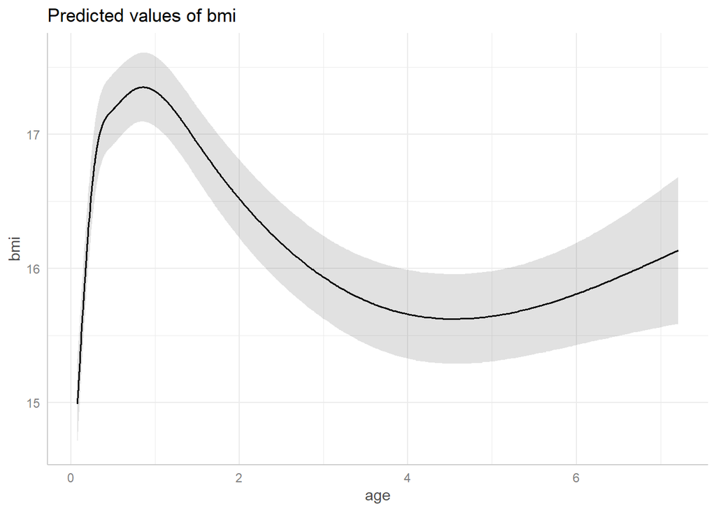

```r
ggeffect(rcs_m_best, terms = c("age [all]")) %>% plot()
```

## Females

Fit models with different knots and select model with lowest BIC

```r
rcs_f <- map(3:6, possibly(~ { eval(parse(text = paste0(
  "lmer(bmi ~ ns(age, ", .x, ") + (ns(age, 2) | id ),
  REML = F, data = dat_f)")))}, otherwise = NA_real_))

(rcs_f_best <- rcs_f[[which.min(unlist(map(rcs_f, BIC)))]])
```

```
## Linear mixed model fit by maximum likelihood  ['lmerMod']
## Formula: bmi ~ ns(age, 4) + (ns(age, 2) | id)
##    Data: dat_f
##       AIC       BIC    logLik  deviance  df.resid
##  2527.544  2586.931 -1251.772  2503.544      1030
## Random effects:
##  Groups   Name        Std.Dev. Corr
##  id       (Intercept) 1.207
##           ns(age, 2)1 2.287    -0.37
##           ns(age, 2)2 1.527    -0.43  0.41
##  Residual             0.605
## Number of obs: 1042, groups:  id, 100
## Fixed Effects:
## (Intercept)  ns(age, 4)1  ns(age, 4)2  ns(age, 4)3  ns(age, 4)4
##     14.5844       2.6122      -0.2276       3.4469       0.4167
```

Print knots positions

```r
attr(terms(rcs_f_best), "predvars")
```

```
## list(bmi, ns(age, knots = c(`25%` = 0.351519158, `50%` = 0.838830521,
## `75%` = 2.24447183625), Boundary.knots = c(0.076364751, 6.916836223
## ), intercept = FALSE))
```

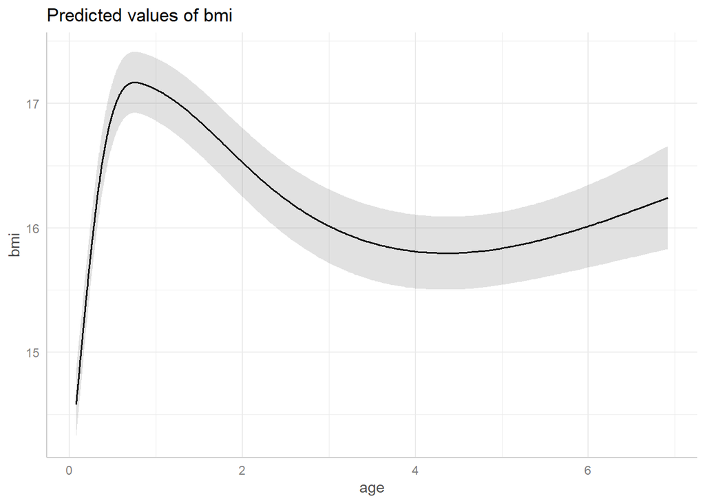

```r
ggeffect(rcs_f_best, terms = c("age [all]")) %>% plot()
```

## Males and females combined

Fit models with different knots and select model with lowest BIC

```r
rcs_mf <- map(3:6, possibly(~ { eval(parse(text = paste0(
  "lmer(bmi ~ ns(age, ", .x, ")* sex + (ns(age, 2) | id ),
  REML = F, data = dat)")))}, otherwise = NA_real_))

(rcs_mf_best <- rcs_mf[[which.min(unlist(map(rcs_mf, BIC)))]])
```

```
## Linear mixed model fit by maximum likelihood  ['lmerMod']
## Formula: bmi ~ ns(age, 5) * sex + (ns(age, 2) | id)
##    Data: dat
##       AIC       BIC    logLik  deviance  df.resid
##  5126.076  5233.366 -2544.038  5088.076      2075
## Random effects:
##  Groups   Name        Std.Dev. Corr
##  id       (Intercept) 1.2711
##           ns(age, 2)1 2.4231   -0.40
##           ns(age, 2)2 1.6602   -0.20  0.29
##  Residual             0.6078
## Number of obs: 2094, groups:  id, 200
## Fixed Effects:
##      (Intercept)       ns(age, 5)1       ns(age, 5)2       ns(age, 5)3
##          14.5809            2.8334            2.1107            0.1937
##      ns(age, 5)4       ns(age, 5)5              sexM  ns(age, 5)1:sexM
##           2.9081            0.8052            0.5122           -0.5027
## ns(age, 5)2:sexM  ns(age, 5)3:sexM  ns(age, 5)4:sexM  ns(age, 5)5:sexM
##          -0.2743           -0.9602           -0.5007           -0.7836
```

Print knots positions

```r
attr(terms(rcs_mf_best), "predvars")
```

```
## list(bmi, ns(age, knots = c(`20%` = 0.2833373708, `40%` = 0.5807503106,
## `60%` = 1.126253912, `80%` = 3.0883893664), Boundary.knots = c(0.07630629,
## 7.208082142), intercept = FALSE), sex)
```

Plot mean BMI trajectory by sex

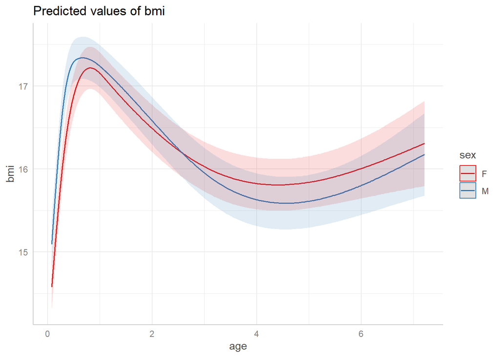

```r
ggeffect(rcs_mf_best, terms = c("age [all]", "sex [all]")) %>% plot()
```

Plot predicted differences by age

```r
(pred_means <- ggemmeans(rcs_mf_best, terms = c(
  "age [0.5, 1, 1.5, 2, 2.5, 3, 3.5, 4, 4.5, 5, 5.5, 6, 6.5, 7]",
  "sex [all]")) %>% as.data.frame())
```

```
##      x predicted std.error conf.low conf.high group
## 1  0.5  16.89126 0.1287270 16.63896  17.14356     F
## 2  0.5  17.29387 0.1280476 17.04291  17.54484     M
## 3  1.0  17.15221 0.1287755 16.89982  17.40461     F
## 4  1.0  17.23835 0.1288267 16.98586  17.49085     M
## 5  1.5  16.80148 0.1374033 16.53218  17.07079     F
## 6  1.5  16.92723 0.1377048 16.65733  17.19712     M
## 7  2.0  16.48906 0.1448021 16.20525  16.77287     F
## 8  2.0  16.58090 0.1454050 16.29591  16.86589     M
## 9  2.5  16.22863 0.1479977 15.93856  16.51870     F
## 10 2.5  16.24210 0.1491266 15.94982  16.53439     M
## 11 3.0  16.02848 0.1525270 15.72953  16.32743     F
## 12 3.0  15.95215 0.1543244 15.64968  16.25462     M
## 13 3.5  15.89537 0.1571447 15.58738  16.20337     F
## 14 3.5  15.74740 0.1595407 15.43470  16.06009     M
## 15 4.0  15.82532 0.1588838 15.51391  16.13672     F
## 16 4.0  15.63030 0.1616168 15.31354  15.94707     M
## 17 4.5  15.80982 0.1586749 15.49882  16.12082     F
## 18 4.5  15.58909 0.1612540 15.27304  15.90514     M
## 19 5.0  15.84038 0.1599935 15.52680  16.15396     F
## 20 5.0  15.61193 0.1616532 15.29510  15.92877     M
## 21 5.5  15.90850 0.1673168 15.58057  16.23643     F
## 22 5.5  15.68700 0.1671411 15.35941  16.01459     M
## 23 6.0  16.00567 0.1840455 15.64494  16.36639     F
## 24 6.0  15.80248 0.1813195 15.44710  16.15786     M
## 25 6.5  16.12338 0.2108353 15.71015  16.53661     F
## 26 6.5  15.94652 0.2053102 15.54412  16.34892     M
## 27 7.0  16.25314 0.2458567 15.77127  16.73501     F
## 28 7.0  16.10732 0.2376572 15.64152  16.57312     M
```

```r
(pred_diff <- map2_df(
  c('1:2', '3:4', '5:6', '7:8', '9:10', '11:12', '13:14',
    '15:16', '17:18','19:20', '21:22', '23:24', '25:26', '27:28'),
  c(0.5, 1, 1.5, 2, 2.5, 3, 3.5, 4, 4.5, 5, 5.5, 6, 6.5, 7), ~ {
    eval(parse(text = paste0("tidy(rma(predicted, sei = std.error, mods = ~ group,
  method = 'FE', data = pred_means[", .x, ",]), conf.int = T) %>% filter(
    term == 'groupM') %>% mutate(age = ", .y, ")")))}))
```

```
## # A tibble: 14 × 9
##    term   type    estimate std.error statistic p.value conf.low conf.high   age
##    <chr>  <chr>      <dbl>     <dbl>     <dbl>   <dbl>    <dbl>     <dbl> <dbl>
##  1 groupM summary   0.403      0.182    2.22    0.0266   0.0468     0.758   0.5
##  2 groupM summary   0.0861     0.182    0.473   0.636   -0.271      0.443   1
##  3 groupM summary   0.126      0.195    0.646   0.518   -0.256      0.507   1.5
##  4 groupM summary   0.0918     0.205    0.448   0.654   -0.310      0.494   2
##  5 groupM summary   0.0135     0.210    0.0642  0.949   -0.398      0.425   2.5
##  6 groupM summary  -0.0763     0.217   -0.352   0.725   -0.502      0.349   3
##  7 groupM summary  -0.148      0.224   -0.661   0.509   -0.587      0.291   3.5
##  8 groupM summary  -0.195      0.227   -0.860   0.390   -0.639      0.249   4
##  9 groupM summary  -0.221      0.226   -0.976   0.329   -0.664      0.223   4.5
## 10 groupM summary  -0.228      0.227   -1.00    0.315   -0.674      0.217   5
## 11 groupM summary  -0.221      0.236   -0.937   0.349   -0.685      0.242   5.5
## 12 groupM summary  -0.203      0.258   -0.786   0.432   -0.710      0.303   6
## 13 groupM summary  -0.177      0.294   -0.601   0.548   -0.754      0.400   6.5
## 14 groupM summary  -0.146      0.342   -0.426   0.670   -0.816      0.524   7
```

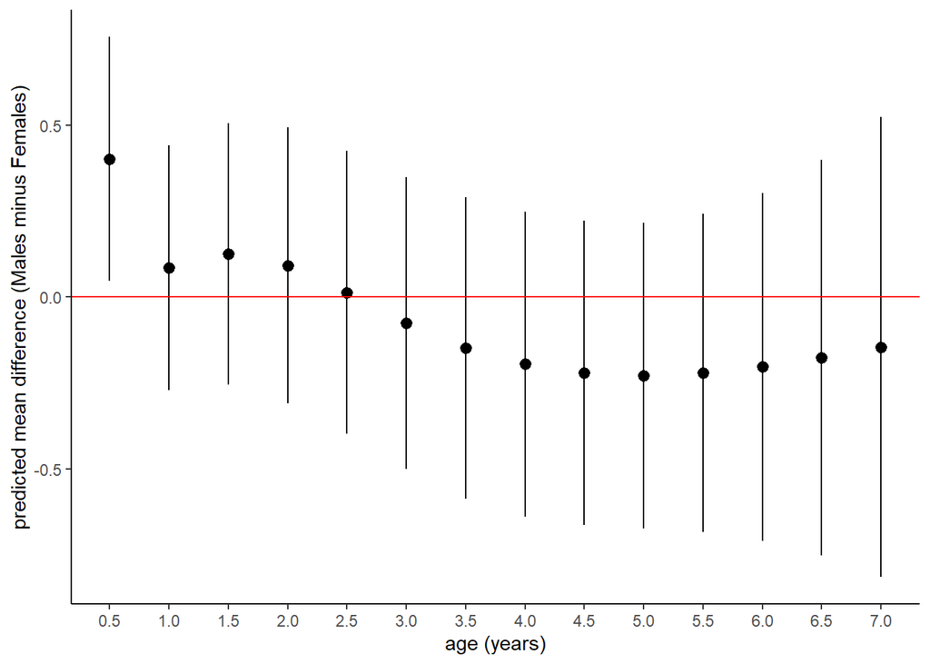

```r
ggplot(data = pred_diff, aes(
  x = age, y = estimate, ymin = conf.low, ymax = conf.high)) + theme_classic() +
  geom_pointrange() + geom_hline(yintercept = 0, col = "red") +scale_x_continuous(
    breaks = c(0.5, 1, 1.5, 2, 2.5, 3, 3.5, 4, 4.5, 5, 5.5, 6, 6.5, 7)) +
  xlab("age (years)") + ylab("predicted mean difference (Males minus Females)")
```

# P-splines

## Males

```r
m_gamm <- gamm(
  bmi ~ s(log(age), bs = 'ps', k = 10, m = c(2, 2)) +
  s(log(age), id, bs = "fs", xt = "ps", k = 10, m = c(2, 1)),
  method = "REML", data = dat_m)
summary(m_gamm$gam)
```

```
##
## Family: gaussian
## Link function: identity
##
## Formula:
## bmi ~ s(log(age), bs = "ps", k = 10, m = c(2, 2)) + s(log(age),
##     id, bs = "fs", xt = "ps", k = 10, m = c(2, 1))
##
## Parametric coefficients:
##             Estimate Std. Error t value Pr(>|t|)
## (Intercept)  16.5457     0.1261   131.2   <2e-16 ***
## ---
## Signif. codes:  0 '***' 0.001 '**' 0.01 '*' 0.05 '.' 0.1 ' ' 1
##
## Approximate significance of smooth terms:
##                    edf  Ref.df     F p-value
## s(log(age))      6.149   6.149 63.12  <2e-16 ***
## s(log(age),id) 346.711 846.000  9.30  <2e-16 ***
## ---
## Signif. codes:  0 '***' 0.001 '**' 0.01 '*' 0.05 '.' 0.1 ' ' 1
##
## R-sq.(adj) =  0.906
##   Scale est. = 0.24216   n = 1052
```

Plot mean BMI trajectory in males

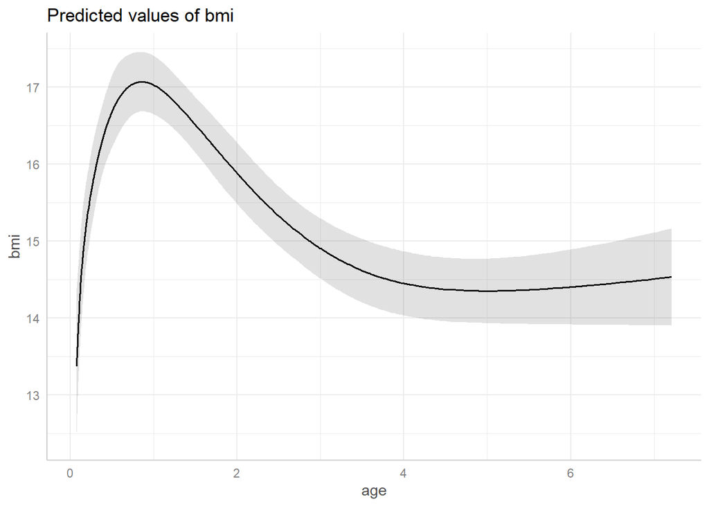

```r
ggpredict(m_gamm, terms = c("age [all]")) %>% plot()
```

## Females

```r
f_gamm <- gamm(
  bmi ~ s(log(age), bs = 'ps', k = 10, m = c(2, 2)) +
    s(log(age), id, bs = "fs", xt = "ps", k = 10, m = c(2, 1)),
  method = "REML", data = dat_f)
summary(f_gamm$gam)
```

```
##
## Family: gaussian
## Link function: identity
##
## Formula:
## bmi ~ s(log(age), bs = "ps", k = 10, m = c(2, 2)) + s(log(age),
##     id, bs = "fs", xt = "ps", k = 10, m = c(2, 1))
##
## Parametric coefficients:
##             Estimate Std. Error t value Pr(>|t|)
## (Intercept)  16.3111     0.1185   137.6   <2e-16 ***
## ---
## Signif. codes:  0 '***' 0.001 '**' 0.01 '*' 0.05 '.' 0.1 ' ' 1
##
## Approximate significance of smooth terms:
##                    edf  Ref.df      F p-value
## s(log(age))      6.469   6.469 69.769  <2e-16 ***
## s(log(age),id) 339.273 852.000  7.598  <2e-16 ***
## ---
## Signif. codes:  0 '***' 0.001 '**' 0.01 '*' 0.05 '.' 0.1 ' ' 1
##
## R-sq.(adj) =  0.894
##   Scale est. = 0.24871   n = 1042
```

Plot mean BMI trajectory in females

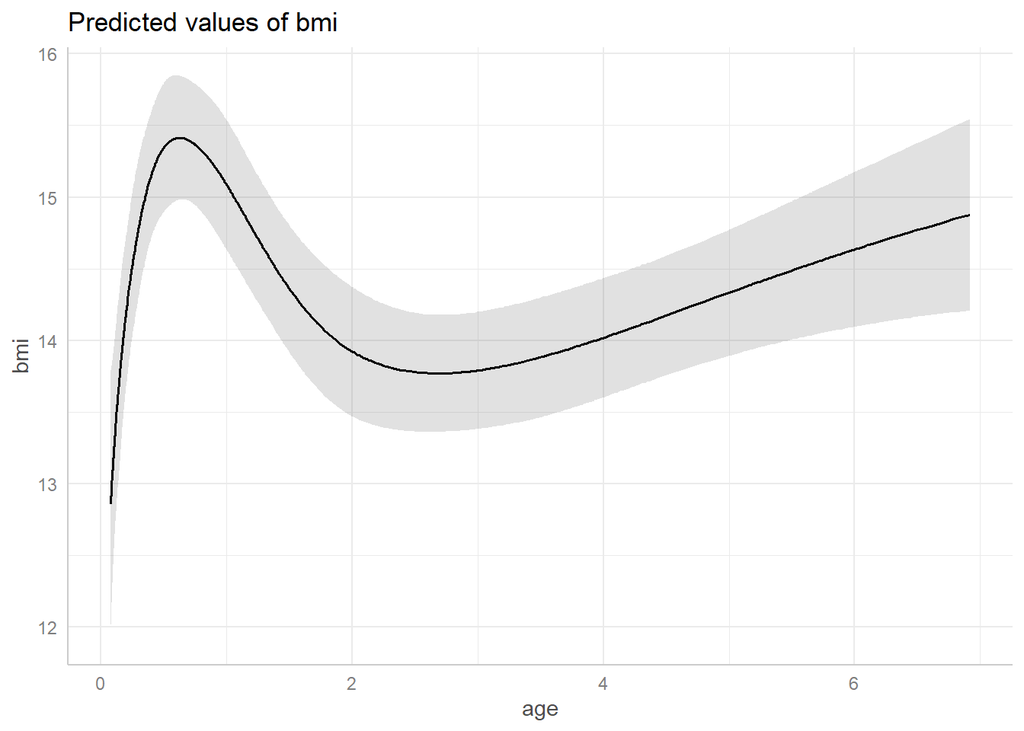

```r
ggpredict(f_gamm, terms = c("age [all]")) %>% plot()
```

## Males and females combined

```r
mf_gamm <- gamm(
  bmi ~ sex + s(log(age), by = sex, bs = 'ps', k = 10, m = c(2, 2)) +
    s(log(age), id, bs = "fs", xt = "ps", k = 10, m = c(2, 1)),
  method = "REML", data = dat)

summary(mf_gamm$gam)
```

```
##
## Family: gaussian
## Link function: identity
##
## Formula:
## bmi ~ sex + s(log(age), by = sex, bs = "ps", k = 10, m = c(2,
##     2)) + s(log(age), id, bs = "fs", xt = "ps", k = 10, m = c(2,
##     1))
##
## Parametric coefficients:
##             Estimate Std. Error t value Pr(>|t|)
## (Intercept)  16.3152     0.1223 133.391   <2e-16 ***
## sexM          0.2271     0.1730   1.313     0.19
## ---
## Signif. codes:  0 '***' 0.001 '**' 0.01 '*' 0.05 '.' 0.1 ' ' 1
##
## Approximate significance of smooth terms:
##                      edf   Ref.df      F p-value
## s(log(age)):sexF   6.454    6.454 67.558  <2e-16 ***
## s(log(age)):sexM   6.150    6.150 65.253  <2e-16 ***
## s(log(age),id)   685.529 1695.000  8.448  <2e-16 ***
## ---
## Signif. codes:  0 '***' 0.001 '**' 0.01 '*' 0.05 '.' 0.1 ' ' 1
##
## R-sq.(adj) =  0.901
##   Scale est. = 0.24547   n = 2094
```

Plot mean BMI trajectory by sex

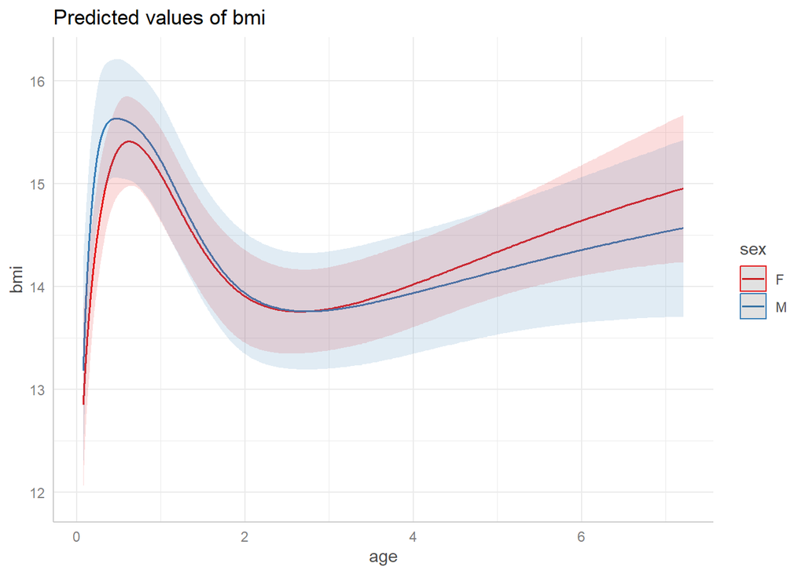

```r
ggpredict(mf_gamm, terms = c("age [all]", "sex [all]")) %>% plot()
```

# SITAR

## Load height dataset

```r
ht_dat <- berkeley %>%
  filter(age >= 5 & age <= 20) %>%
  select(id, sex, age, height) %>%
  drop_na()

ht_dat_m <- ht_dat %>% filter(sex == 1)
ht_dat_f <- ht_dat %>% filter(sex == 2)
```

Quick look at the data

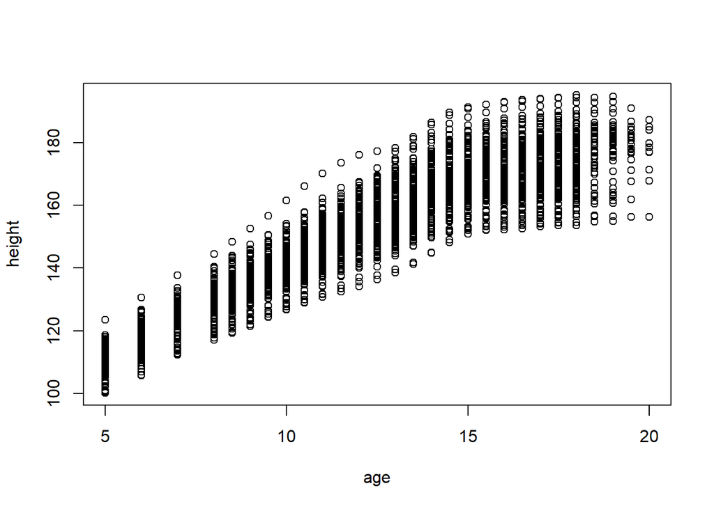

```r
with(ht_dat, plot(age, height))
```

```r
ht_dat %>% group_by(sex) %>% summarise(N = n_distinct(id))
```

```
## # A tibble: 2 × 2
##   sex       N
##   <fct> <int>
## 1 1        66
## 2 2        70
```

```r
ht_dat %>% group_by(id) %>% count() %>% ungroup() %>%
  summarise(median(n), min(n), max(n))
```

```
## # A tibble: 1 × 3
##   `median(n)` `min(n)` `max(n)`
##         <dbl>    <int>    <int>
## 1          24       24       28
```

## Males

```r
sitar_ht_m <- map(3:6, possibly(~ { eval(parse(text = paste0(
  "sitar(x = log(age), y = log(height), id = id, data = ht_dat_m, df = ", .x, ")"
)))}, otherwise = NA_real_))

(sitar_ht_m_bic <- unlist(map(sitar_ht_m, BICadj)))
```

```
## .x[[i]] .x[[i]] .x[[i]] .x[[i]]
##  5451.0  5382.4  5364.1  5271.9
```

```r
(sitar_ht_m_best <- sitar_ht_m[[which.min(sitar_ht_m_bic)]])
```

```
## SITAR nonlinear mixed-effects model fit by maximum likelihood
##   Call: sitar(x = log(age), y = log(height), id = id, data = ht_dat_m,
##     df = 6)
##   Log-likelihood: 5919.251
##   Fixed: s1 + s2 + s3 + s4 + s5 + s6 + a + b + c ~ 1
##         s1         s2         s3         s4         s5         s6          a
## 0.27086727 0.32761284 0.46538152 0.43719724 0.61650829 0.41510717 4.70360482
##          b          c
## 0.01710226 0.02366948
##
## Random effects:
##  Formula: list(a ~ 1, b ~ 1, c ~ 1)
##  Level: id
##  Structure: General positive-definite, Log-Cholesky parametrization
##          StdDev     Corr
## a        0.03519408 a      b
## b        0.06661631  0.061
## c        0.08010354  0.222 -0.397
## Residual 0.00534707
##
## Number of Observations: 1689
## Number of Groups: 66
```

Plot mean height growth and velocity curves for males

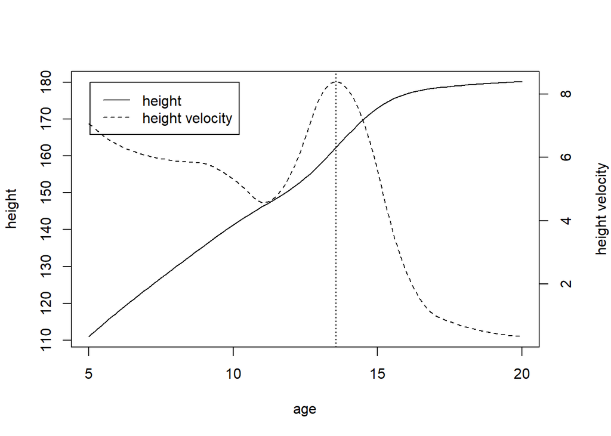

```
##   apv    pv
## 13.57  8.39
```

```r
plot(sitar_ht_m_best, apv = T)
```

## Females

```r
sitar_ht_f <- map(3:6, possibly(~ { eval(parse(text = paste0(
  "sitar(x = log(age), y = log(height), id = id, data = ht_dat_f, df = ", .x, ")"
)))}, otherwise = NA_real_))

(sitar_ht_f_bic <- unlist(map(sitar_ht_f, BICadj)))
```

```
## .x[[i]] .x[[i]] .x[[i]] .x[[i]]
##  4491.0  4463.3  4431.8  4435.5
```

```r
(sitar_ht_f_best <- sitar_ht_f[[which.min(sitar_ht_f_bic)]])
```

```
## SITAR nonlinear mixed-effects model fit by maximum likelihood
##   Call: sitar(x = log(age), y = log(height), id = id, data = ht_dat_f,
##     df = 5)
##   Log-likelihood: 6347.16
##   Fixed: s1 + s2 + s3 + s4 + s5 + a + b + c ~ 1
##           s1           s2           s3           s4           s5            a
## 0.2115123171 0.3102452136 0.2987417827 0.4362472987 0.2807999004 4.7735105313
##            b            c
## 0.0000323945 0.3566093832
##
## Random effects:
##  Formula: list(a ~ 1, b ~ 1, c ~ 1)
##  Level: id
##  Structure: General positive-definite, Log-Cholesky parametrization
##          StdDev      Corr
## a        0.035691088 a      b
## b        0.069282545  0.087
## c        0.072214671  0.210 -0.190
## Residual 0.004102693
##
## Number of Observations: 1701
## Number of Groups: 70
```

Plot mean height growth and velocity curves for females

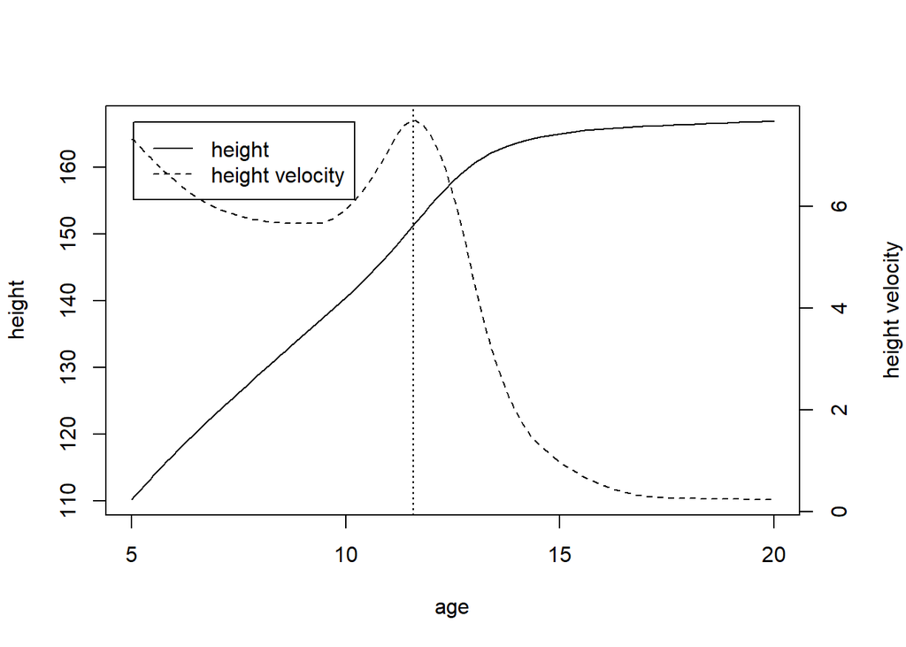

```
##    apv     pv
## 11.580  7.677
```

```r
plot(sitar_ht_f_best, apv = T)
```

Plot mean height growth and velocity curves for males and females

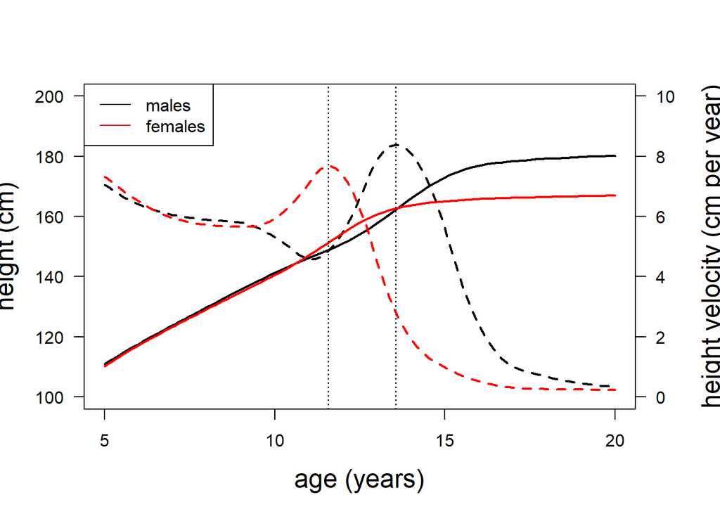

```r
plot(
  sitar_ht_m_best, las = 1, apv = T,
  legend = NULL,  ylim = c(100, 200), vlim = c(0, 10),
  vlab = "", ylab = "", xlab = "", y2par = list(lwd = 2),
  lwd = 2, font.main = 1, adj  = 0
)

lines(
  sitar_ht_f_best,
  y2par = list(col = 'red', lwd = 2),
  apv = T, lwd = 2, col = 'red'
)

mtext("age (years)", side = 1, line = 3, cex = 1.5)
mtext("height (cm)", side = 2, line = 3.25, cex = 1.5)
mtext("height velocity (cm per year)", side = 4, line = 3.3, cex = 1.5)
legend("topleft", c( "males", "females"), col = c("black", "red"), lty = c(1, 1))
```